# YouTube Algorithm: Track YouTube Ads Data With Visualisation to Find Its Patterns

[figure not shown]

## The focus of my data story

In this modern age, the websites we use contain algorithms in order to track their consumers’ behaviour and preferences in order to find ways to attract each different consumer to their preferences. YouTube must be no different than the many websites, which is why the focus of my data story involves recording the details of YouTube ads into data.

Throughout late March when I did Project2, I collected data for 53 YouTube ads. Now, while doing this project(Project4), I decided to collect data for 21 more YouTube ads in order to see if there is any major effect of time in around a month on how it changes the usual details such as how relevant the ads are to me and the Timespan of Ad.

I hope to find out if there is any such thing as a YouTube algorithm that trackes your preferences throughout what you do in Google and gives you each ads according to your preferences (aka how relevant it is to me).

## Is there a relationship between how long an ad is and how relevent it is to me?

To answer this question, I decided to use a boxplot in order to find out if ads that are more relevant to me would be given a longer period of time for me to watch (as what I would predict).

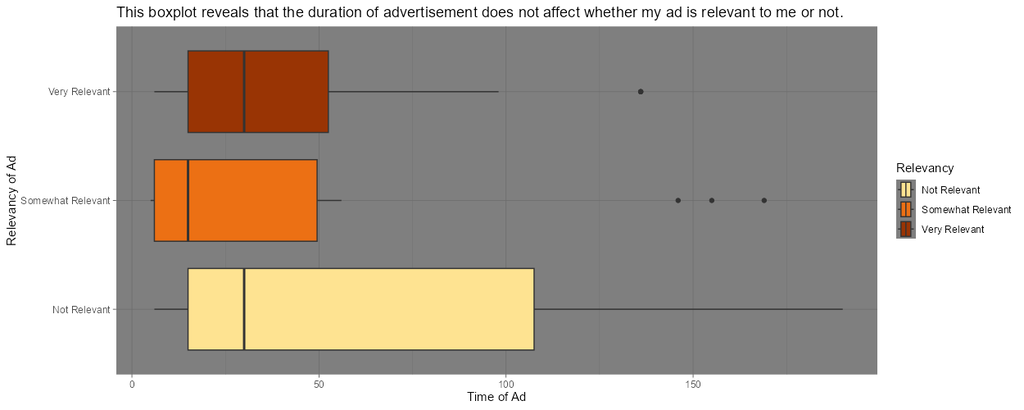

This boxplot reveals that the duration of advertisement does not affect whether my ad is relevant to me or not.

There does not really seem to be a significant relationship between the relevancy of the ad and how long the ad lasts when we make a box plot to check the minimums, lower quartiles, medians, upper quartiles, and maximums.

## Does the type of ad given have any relation to the average time of the type of ad?

So, I decided to use new variables to see if there is any relationship between the mean time of ad for each type and the type of ad in order to find my hypothesized algorithm in YouTube. After all, money related ads tend to be more relevant to me. I decided that a barplot that differentiates the relevancy for each type of ad would be something important to compare to when finding my hypothesized algorithm.

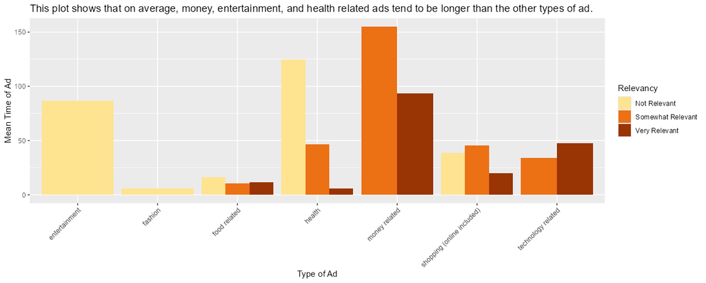

This plot shows that on average, money, entertainment, and health related ads tend to be longer than the other types of ad.

According to the barplot, it looks like ads that are related to money, entertainment, and health has the longest mean time of the ads. Even though most health ads and all the entertainment ads are not relevant to me, money ads are. So, it is pretty uncertain on whether a hypothesized algorithm exists or not.

## Does the date of when the ad occured have any relation to how I would rate the ad?

Then, I decided to check another factor that proves the existence of a YouTube algorithm: the date and time of when I encounter and log in each ad and how it relates to how I rate those ads. I also differentiated the points with different colours by the type of ads. It is possible that during sometime closer to a holiday, there might be more promotions of sales and similar examples as well. So, I decided to use a scatterplot to find a relationship for the hypothesized algorithm.

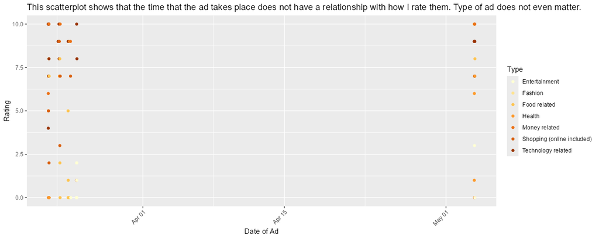

This scatterplot shows that the time that the ad takes place does not have a relationship with how I rate them. Type of ad does not even matter.

Sadly, I do not find any relationship between how I rate the ads and the date/time. There is also no relationship between date/time of ads and the type of ads.

## Conclusions

### Much Appreciated For Checking Out My Story of Constant Ads!

[figure not shown]